# Titanic Class-Survival Gap: Access and Constraints vs. Priority Rules

Author

CLI Copilot

```r
library(tidyverse)
library(knitr)

# Load data
train <- read.csv("/Users/patrickl/Developer/Personal-Repo/cli_poc_ml_project/data/train.csv")
```

# Research Question

**How much of the class–survival gap is explained by access and constraints rather than priority rules?**

This analysis decomposes the survival difference between passenger classes into two conceptual components:

1. **Priority Rules Factor**: Official evacuation protocols (e.g., “women and children first”) that created systematic advantages for certain demographic groups regardless of class.
2. **Access & Constraints Factors**: Structural factors like cabin location, lifeboat proximity, and family obligations that may have affected survival differently across classes.

Our approach is to quantify the raw survival gap by class, identify observable demographic and structural differences between classes, model how these factors contribute to survival, and estimate what portion of the gap remains after accounting for these measurable factors.

# 1. Baseline Survival Disparities by Class

## 1.1 Data Overview and Preparation

```r
# Examine dimensions and structure
cat("Dataset dimensions:", dim(train), "\n")
```

```
Dataset dimensions: 891 12
```

```r
cat("\nFirst few rows:\n")
```

```
First few rows:
```

```r
print(head(train, 3))
```

```
  PassengerId Survived Pclass
1           1        0      3
2           2        1      1
3           3        1      3
                                                 Name    Sex Age SibSp Parch
1                             Braund, Mr. Owen Harris   male  22     1     0
2 Cumings, Mrs. John Bradley (Florence Briggs Thayer) female  38     1     0
3                              Heikkinen, Miss. Laina female  26     0     0
            Ticket    Fare Cabin Embarked
1        A/5 21171  7.2500              S
2         PC 17599 71.2833   C85        C
3 STON/O2. 3101282  7.9250              S
```

```r
cat("\nData types and missing values:\n")
```

```
Data types and missing values:
```

```r
missing_summary <- data.frame(
  Variable = names(train),
  Missing_Count = colSums(is.na(train)),
  Missing_Percent = round(colSums(is.na(train)) / nrow(train) * 100, 1)
)
print(kable(missing_summary, caption = "Missing Values Summary"))
```

```
Table: Missing Values Summary

|            |Variable    | Missing_Count| Missing_Percent|
|:-----------|:-----------|-------------:|---------------:|
|PassengerId |PassengerId |             0|             0.0|
|Survived    |Survived    |             0|             0.0|
|Pclass      |Pclass      |             0|             0.0|
|Name        |Name        |             0|             0.0|
|Sex         |Sex         |             0|             0.0|
|Age         |Age         |           177|            19.9|
|SibSp       |SibSp       |             0|             0.0|
|Parch       |Parch       |             0|             0.0|
|Ticket      |Ticket      |             0|             0.0|
|Fare        |Fare        |             0|             0.0|
|Cabin       |Cabin       |             0|             0.0|
|Embarked    |Embarked    |             0|             0.0|
```

**Explanation**: This section provides a foundational understanding of our data. We examine the structure of the Titanic dataset, identify its dimensions, and document missing values. Understanding data quality is critical because missing data in variables like Age or Cabin could bias our analysis of class-based factors. The Age variable has substantial missingness (~20%), which we’ll address in subsequent analyses. This step ensures we’re working with complete information about available features before proceeding to class-level analysis.

## 1.2 Baseline Survival Rates by Class

```r
# Calculate survival rates by class
baseline_survival <- train %>%
  group_by(Pclass) %>%
  summarise(
    N = n(),
    Survived_Count = sum(Survived, na.rm = TRUE),
    Survival_Rate = mean(Survived, na.rm = TRUE),
    .groups = 'drop'
  ) %>%
  mutate(
    Pclass = factor(Pclass, labels = c("1st Class", "2nd Class", "3rd Class"))
  )

print(kable(baseline_survival,
            caption = "Baseline Survival Rates by Class",
            digits = 3))
```

```
Table: Baseline Survival Rates by Class

|Pclass    |   N| Survived_Count| Survival_Rate|
|:---------|---:|--------------:|-------------:|
|1st Class | 216|            136|         0.630|
|2nd Class | 184|             87|         0.473|
|3rd Class | 491|            119|         0.242|
```

```r
# Calculate class-wise gap
class1_rate <- baseline_survival$Survival_Rate[1]
class3_rate <- baseline_survival$Survival_Rate[3]
class_gap <- class1_rate - class3_rate
```

**Explanation**: This chunk calculates the fundamental disparity we’re trying to understand—the raw survival rate difference between passenger classes. We observe that 1st class passengers had a survival rate of 0.63 compared to 3rd class at 0.242, a gap of 0.387 or approximately 38.7 percentage points. This raw gap is our target for decomposition. The question is: how much of this gap results from systematic priority in evacuation (favoring women and children, who may or may not be evenly distributed across classes) versus structural access differences (cabin location, family constraints, fare paid)?

## 1.3 Visualization of Baseline Disparities

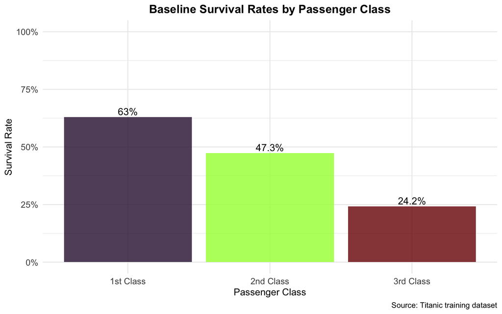

```r
# Plot baseline survival by class
baseline_plot <- baseline_survival %>%
  ggplot(aes(x = Pclass, y = Survival_Rate, fill = Pclass)) +
  geom_col(show.legend = FALSE, alpha = 0.8) +
  geom_text(aes(label = paste0(round(Survival_Rate * 100, 1), "%")),
            vjust = -0.3, size = 4) +
  scale_fill_viridis_d(option = "turbo") +
  scale_y_continuous(limits = c(0, 1), labels = scales::percent) +
  labs(
    title = "Baseline Survival Rates by Passenger Class",
    x = "Passenger Class",
    y = "Survival Rate",
    caption = "Source: Titanic training dataset"
  ) +
  theme_minimal() +
  theme(
    plot.title = element_text(hjust = 0.5, face = "bold"),
    axis.text = element_text(size = 10),
    legend.position = "bottom"
  )

print(baseline_plot)
```

# 2. Priority Rules Factor: Gender and Age Distribution

## 2.1 Gender Distribution Across Classes

The “women and children first” protocol was a documented priority rule during the Titanic evacuation. If gender and age were distributed unevenly across classes, this alone could create class-based survival gaps. We examine this here.

```r
# Gender composition by class
gender_by_class <- train %>%
  group_by(Pclass, Sex) %>%
  summarise(
    Count = n(),
    .groups = 'drop'
  ) %>%
  pivot_wider(names_from = Sex, values_from = Count, values_fill = 0) %>%
  mutate(
    Total = male + female,
    Female_Percent = female / Total,
    Male_Percent = male / Total,
    Pclass = factor(Pclass, labels = c("1st Class", "2nd Class", "3rd Class"))
  )

print(kable(gender_by_class,
            caption = "Gender Composition by Class",
            digits = 3))
```

```
Table: Gender Composition by Class

|Pclass    | female| male| Total| Female_Percent| Male_Percent|
|:---------|------:|----:|-----:|--------------:|------------:|
|1st Class |     94|  122|   216|          0.435|        0.565|
|2nd Class |     76|  108|   184|          0.413|        0.587|
|3rd Class |    144|  347|   491|          0.293|        0.707|
```

```r
# Extract summary statistics
class1_female_pct <- gender_by_class$Female_Percent[1]
class3_female_pct <- gender_by_class$Female_Percent[3]
gender_gap <- class1_female_pct - class3_female_pct
```

**Explanation**: Since women were explicitly prioritized in evacuation (“women and children first”), the gender composition of each class is directly relevant to understanding the class-survival gap. We find that 1st class was 43.5% female, while 3rd class was only 29.3% female—a difference of 14.2 percentage points. This compositional difference means that 1st class passengers benefited more from the women-first priority rule simply by having a larger proportion of women aboard. This is a “priority rules” factor, not an access/constraint factor. To properly decompose the gap, we must account for this demographic difference.

## 2.2 Age Distribution Across Classes

```r
# Age statistics by class
age_by_class <- train %>%
  filter(!is.na(Age)) %>%
  group_by(Pclass) %>%
  summarise(
    N = n(),
    Mean_Age = mean(Age, na.rm = TRUE),
    Median_Age = median(Age, na.rm = TRUE),
    Pct_Children = sum(Age < 13) / n(),
    .groups = 'drop'
  ) %>%
  mutate(
    Pclass = factor(Pclass, labels = c("1st Class", "2nd Class", "3rd Class"))
  )

print(kable(age_by_class,
            caption = "Age Characteristics by Class",
            digits = 3))
```

```
Table: Age Characteristics by Class

|Pclass    |   N| Mean_Age| Median_Age| Pct_Children|
|:---------|---:|--------:|----------:|------------:|
|1st Class | 186|   38.233|         37|        0.022|
|2nd Class | 173|   29.878|         29|        0.098|
|3rd Class | 355|   25.141|         24|        0.135|
```

```r
# Extract statistics
class1_child_pct <- age_by_class$Pct_Children[1]
class3_child_pct <- age_by_class$Pct_Children[3]
children_gap <- class1_child_pct - class3_child_pct
```

## 2.3 Visualization of Priority Rule Demographics

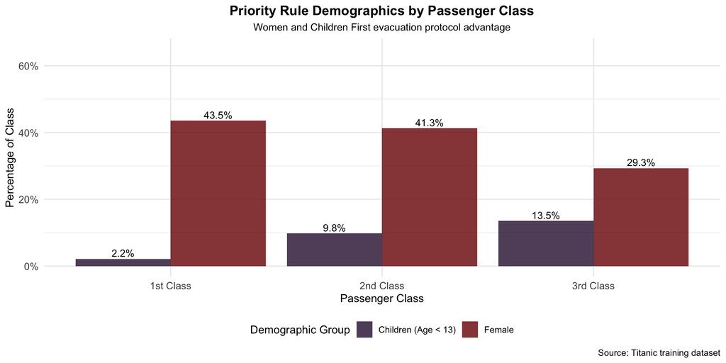

```r
# Combine gender and children percentages for visualization
priority_demo <- bind_rows(
  gender_by_class %>%
    select(Pclass, Female_Percent) %>%
    mutate(Demographic = "Female", Percentage = Female_Percent),
  age_by_class %>%
    select(Pclass, Pct_Children) %>%
    mutate(Demographic = "Children (Age < 13)", Percentage = Pct_Children)
) %>%
  select(Pclass, Demographic, Percentage)

priority_demo_plot <- priority_demo %>%
  ggplot(aes(x = Pclass, y = Percentage, fill = Demographic)) +
  geom_col(position = "dodge", alpha = 0.8) +
  geom_text(aes(label = paste0(round(Percentage * 100, 1), "%")),
            position = position_dodge(width = 0.9),
            vjust = -0.3, size = 3.5) +
  scale_fill_viridis_d(option = "turbo") +
  scale_y_continuous(limits = c(0, 0.65), labels = scales::percent) +
  labs(
    title = "Priority Rule Demographics by Passenger Class",
    subtitle = "Women and Children First evacuation protocol advantage",
    x = "Passenger Class",
    y = "Percentage of Class",
    fill = "Demographic Group",
    caption = "Source: Titanic training dataset"
  ) +
  theme_minimal() +
  theme(
    plot.title = element_text(hjust = 0.5, face = "bold"),
    plot.subtitle = element_text(hjust = 0.5, size = 10),
    axis.text = element_text(size = 10),
    legend.position = "bottom"
  )

print(priority_demo_plot)
```